# Trabajo final

Indicaciones:

1. Utilizando scipy. stats, crea un programa que modele la probabilidad de obtener un

número específico de éxitos en una serie de lanzamientos de una moneda sin trucos (probabilidad de éxito p = 0. 5). Genera la probabilidad de obtener exactamente 7 caras en 10 lanzamientos

```python
#IMPORTACION INICIAL
import numpy as np
import scipy.stats as stats
import matplotlib.pyplot as plt
```

```python
prob_7_caras = stats.binom.pmf(7, 10, 0.5)
print(f"Probabilidad de obtener exactamente 7 caras en 10 lanzamientos: {prob_7_caras:.4f}")
```

```
Probabilidad de obtener exactamente 7 caras en 10 lanzamientos: 0.1172
```

Calcula la probabilidad acumulada de obtener 7 o menos caras en 10 lanzamientos

```python
prob_acumulada_7 = stats.binom.cdf(7, 10, 0.5)
print(f"Probabilidad acumulada de obtener 7 o menos caras en 10 lanzamientos: {prob_acumulada_7:.4f}")
```

```
Probabilidad acumulada de obtener 7 o menos caras en 10 lanzamientos: 0.9453
```

Grafica la distribución binomial completa para los 10 lanzamientos, mostrando la probabilidad de obtener desde 0 hasta 10 caras.

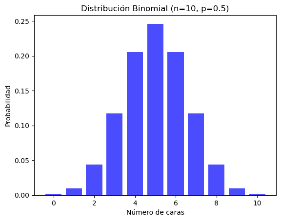

```python
# EJERCICIO 3 PARTE 1: GRAFICA DE DISTRIBUCION BINOMIAL X, Y,    p/z=0.5
x = np.arange(0, 11)  # Posibles resultados de caras (0 a 10)
y = stats.binom.pmf(x, 10, 0.5)  # Probabilidades

plt.bar(x, y, color='blue', alpha=0.7)
plt.xlabel('Número de caras')
plt.ylabel('Probabilidad')
plt.title('Distribución Binomial (n=10, p=0.5)')
plt.show()
```

Ahora la moneda tiene mayor probabilidad de caer en cara (probabilidad de éxito p = 0. 8). ¿Cómo cambian los resultados? Vuelve a realizar los ejercicios I, II y III.

```
Probabilidad de obtener exactamente 7 caras con p=0.8: 0.2013
Probabilidad acumulada de obtener 7 o menos caras con p=0.8: 0.3222
```

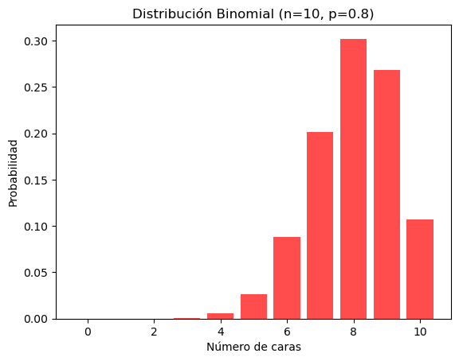

```python
prob_7_caras_p8 = stats.binom.pmf(7, 10, 0.8)
prob_acumulada_7_p8 = stats.binom.cdf(7, 10, 0.8)

print(f"Probabilidad de obtener exactamente 7 caras con p=0.8: {prob_7_caras_p8:.4f}")
print(f"Probabilidad acumulada de obtener 7 o menos caras con p=0.8: {prob_acumulada_7_p8:.4f}")

#GRAFICA NUEVA
y_p8 = stats.binom.pmf(x, 10, 0.8)
plt.bar(x, y_p8, color='red', alpha=0.7)
plt.xlabel('Número de caras')
plt.ylabel('Probabilidad')
plt.title('Distribución Binomial (n=10, p=0.8)')
plt.show()
```

Utilizando scipy. stats, realiza un análisis de una distribución normal con una media de 0 y desviación estándar de 1. Genera un conjunto de datos aleatorios con 1000 muestras a partir de esta distribución.

```python
datos = stats.norm.rvs(loc=0, scale=1, size=1000)
print(datos)
```

[output not shown]

[output cut: 195 more lines]

[output not shown]

Calcula y muestra la media, la desviación estándar y la mediana de los datos generados.

```python
media = np.mean(datos)
desviacion = np.std(datos)
mediana = np.median(datos)

print(f"Media de los datos: {media:.4f}")
print(f"Desviación estándar de los datos: {desviacion:.4f}")
print(f"Mediana de los datos: {mediana:.4f}")
```

```
Media de los datos: -0.0297
Desviación estándar de los datos: 1.0427
Mediana de los datos: -0.0039
```

Grafica el histograma de los datos y superpón la curva de la distribución normal teórica.

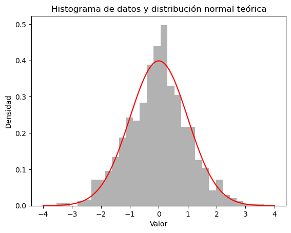

```python
plt.hist(datos, bins=30, density=True, alpha=0.6, color='gray')

# CUTVA
x_vals = np.linspace(-4, 4, 100)
y_vals = stats.norm.pdf(x_vals, loc=0, scale=1)
plt.plot(x_vals, y_vals, color='red')

plt.xlabel('Valor')
plt.ylabel('Densidad')
plt.title('Histograma de datos y distribución normal teórica')
plt.show()
```

Calcula la probabilidad de que un valor caiga dentro del rango de -1 a 1 (una desviación estándar de la media).

```python
prob_rango = stats.norm.cdf(1, 0, 1) - stats.norm.cdf(-1, 0, 1)
print(f"Probabilidad de estar dentro del rango [-1,1]: {prob_rango:.4f}")
```

```
Probabilidad de estar dentro del rango [-1,1]: 0.6827
```

# Parte 2

Contaran con toda la información sobre el trabajo en la carpeta "Trabajo Final" del Github de curso. Lean con cuidado las indicaciones. Algunos puntos a tener en cuenta:

Puedes elegir una de estas dos opciones

- Indicadores de Desarrollo GlobaL, a nivel país.
- El IDH, a nivel distrital, provincial o departamental.

Realiza 4 gráficos con la base de datos de tu elección. Ojo que cualquiera de las opciones implica realizar alguna limpieza de los datos.

Aquí van algunas ideas:

Para los indicadores de desarrollo global:

- puedes ver la evolución en el tiempo de un sólo indicador, para un sólo pais, o región.
- Puedes hacer la comparación entre la evolucion de varios países.
- puedes ver la comparación entre países de un sólo indicador. Puedes enfocarte en una o varias regiones.
- puedes ver la relación de dos o más indicadores.

Para el IDH:

- puedes ver la comparación de alguno de los indicadores entre distritos dentro de un departamento.
- puedes ver la relación de dos indicadores que componen el IDH, entre ellos.

Hay más opciones de temas para los indicadores de desarrollo global.

Formato de entrega: Un archivo txt con la URL de la web en Github o notebook del trabajo que también incluya la URL de la web en github. Tener en consideración que dado que el trabajo es de grupos de 5 solo sera necesario que este publicado en un Github. Además dentro de la pagina de Github del trabajo final esta un tutorial de como publicar sus paginas en formato html.

## Ha sido un gusto poder enseñarles . Hasta pronto :D

(╯°□°）╯︵ ┻━┻

```python
!pip install pandas
import pandas as pd
```

```python
data_excel = pd.read_excel('IDH_PNUD_2017-1 (1).xlsx')
data_excel.head()
```

|  | Índice de Desarollo Humano IDH 2017 | Unnamed: 1 | Unnamed: 2 | Unnamed: 3 | Unnamed: 4 | Unnamed: 5 | Unnamed: 6 | Unnamed: 7 | Unnamed: 8 | Unnamed: 9 | Unnamed: 10 | Unnamed: 11 | Unnamed: 12 | Unnamed: 13 | Unnamed: 14 | Unnamed: 15 | Unnamed: 16 | Unnamed: 17 |
| --- | --- | --- | --- | --- | --- | --- | --- | --- | --- | --- | --- | --- | --- | --- | --- | --- | --- | --- |
| 0 | NaN | NaN | NaN | NaN | NaN | NaN | NaN | Logro educativo | NaN | NaN | NaN | NaN | NaN | Valores normalizados | NaN | NaN | NaN | NaN |
| 1 | UBIGEO | DEPARTAMENTO | NaN | NaN | NaN | Población total | Esperanza de vida al nacer | Población (18 años) con Educ. secundaria completa | Años de educación (Poblac. 25 y más) | Ingreso familiar per cápita | NaN | Índice de Desarrollo Humano (IDH) | NaN | Esperanza de vida al nacer | Población (18 años) con Educ. secundaria completa | Años de educación (Poblac. 25 y más) | Logro educativo | Ingreso familiar per cápita |
| 2 | NaN | NaN | Provincia | NaN | NaN | NaN | NaN | NaN | NaN | NaN | NaN | NaN | NaN | NaN | NaN | NaN | NaN | NaN |
| 3 | NaN | NaN | Distrito | NaN | NaN | habitantes | Años | (%) | Años | N.S. mes | NaN | NaN | NaN | NaN | NaN | NaN | NaN | NaN |
| 4 | NaN | NaN | NaN | NaN | NaN | NaN | NaN | NaN | NaN | NaN | NaN | NaN | NaN | NaN | NaN | NaN | NaN | NaN |

```python
df_2=pd.read_excel('IDH_PNUD_2017-1 (1).xlsx')
df_2
```

|  | Índice de Desarollo Humano IDH 2017 | Unnamed: 1 | Unnamed: 2 | Unnamed: 3 | Unnamed: 4 | Unnamed: 5 | Unnamed: 6 | Unnamed: 7 | Unnamed: 8 | Unnamed: 9 | Unnamed: 10 | Unnamed: 11 | Unnamed: 12 | Unnamed: 13 | Unnamed: 14 | Unnamed: 15 | Unnamed: 16 | Unnamed: 17 |
| --- | --- | --- | --- | --- | --- | --- | --- | --- | --- | --- | --- | --- | --- | --- | --- | --- | --- | --- |
| 0 | NaN | NaN | NaN | NaN | NaN | NaN | NaN | Logro educativo | NaN | NaN | NaN | NaN | NaN | Valores normalizados | NaN | NaN | NaN | NaN |
| 1 | UBIGEO | DEPARTAMENTO | NaN | NaN | NaN | Población total | Esperanza de vida al nacer | Población (18 años) con Educ. secundaria completa | Años de educación (Poblac. 25 y más) | Ingreso familiar per cápita | NaN | Índice de Desarrollo Humano (IDH) | NaN | Esperanza de vida al nacer | Población (18 años) con Educ. secundaria completa | Años de educación (Poblac. 25 y más) | Logro educativo | Ingreso familiar per cápita |
| 2 | NaN | NaN | Provincia | NaN | NaN | NaN | NaN | NaN | NaN | NaN | NaN | NaN | NaN | NaN | NaN | NaN | NaN | NaN |
| 3 | NaN | NaN | Distrito | NaN | NaN | habitantes | Años | (%) | Años | N.S. mes | NaN | NaN | NaN | NaN | NaN | NaN | NaN | NaN |
| 4 | NaN | NaN | NaN | NaN | NaN | NaN | NaN | NaN | NaN | NaN | NaN | NaN | NaN | NaN | NaN | NaN | NaN | NaN |
| ... | ... | ... | ... | ... | ... | ... | ... | ... | ... | ... | ... | ... | ... | ... | ... | ... | ... | ... |
| 2299 | 250401 | 1 | Purus | NaN | NaN | 2860 | 66.458846 | 20.197044 | 7.2707 | 517.759563 | NaN | 0.335455 | NaN | 0.690981 | 0.20197 | 0.385261 | 0.278947 | 0.195846 |
| 2300 | NaN | NaN | NaN | NaN | NaN | NaN | NaN | NaN | NaN | NaN | NaN | NaN | NaN | NaN | NaN | NaN | NaN | NaN |
| 2301 | Fuente: INEI. Censo de Población y Vivienda 20... | NaN | NaN | NaN | NaN | NaN | NaN | NaN | NaN | NaN | NaN | NaN | NaN | NaN | NaN | NaN | NaN | NaN |
| 2302 | Elaboración: PNUD / Unidad del Informe sobre D... | NaN | NaN | NaN | NaN | NaN | NaN | NaN | NaN | NaN | NaN | NaN | NaN | NaN | NaN | NaN | NaN | NaN |
| 2303 | 1/ Provincias de Lima y Callao. | NaN | NaN | NaN | NaN | NaN | NaN | NaN | NaN | NaN | NaN | NaN | NaN | NaN | NaN | NaN | NaN | NaN |

2304 rows × 18 columns

```python
import pandas as pd
import numpy as np
!pip install matplotlib
df_2 = pd.read_excel('IDH_PNUD_2017-1 (1).xlsx')  # Cargar el archivo
df_2 = df_2.iloc[1:].reset_index(drop=True)
df_2
```

|  | Índice de Desarollo Humano IDH 2017 | Unnamed: 1 | Unnamed: 2 | Unnamed: 3 | Unnamed: 4 | Unnamed: 5 | Unnamed: 6 | Unnamed: 7 | Unnamed: 8 | Unnamed: 9 | Unnamed: 10 | Unnamed: 11 | Unnamed: 12 | Unnamed: 13 | Unnamed: 14 | Unnamed: 15 | Unnamed: 16 | Unnamed: 17 |
| --- | --- | --- | --- | --- | --- | --- | --- | --- | --- | --- | --- | --- | --- | --- | --- | --- | --- | --- |
| 0 | UBIGEO | DEPARTAMENTO | NaN | NaN | NaN | Población total | Esperanza de vida al nacer | Población (18 años) con Educ. secundaria completa | Años de educación (Poblac. 25 y más) | Ingreso familiar per cápita | NaN | Índice de Desarrollo Humano (IDH) | NaN | Esperanza de vida al nacer | Población (18 años) con Educ. secundaria completa | Años de educación (Poblac. 25 y más) | Logro educativo | Ingreso familiar per cápita |
| 1 | NaN | NaN | Provincia | NaN | NaN | NaN | NaN | NaN | NaN | NaN | NaN | NaN | NaN | NaN | NaN | NaN | NaN | NaN |
| 2 | NaN | NaN | Distrito | NaN | NaN | habitantes | Años | (%) | Años | N.S. mes | NaN | NaN | NaN | NaN | NaN | NaN | NaN | NaN |
| 3 | NaN | NaN | NaN | NaN | NaN | NaN | NaN | NaN | NaN | NaN | NaN | NaN | NaN | NaN | NaN | NaN | NaN | NaN |
| 4 | NaN | NaN | NaN | NaN | NaN | NaN | NaN | NaN | NaN | NaN | NaN | NaN | NaN | NaN | NaN | NaN | NaN | NaN |
| ... | ... | ... | ... | ... | ... | ... | ... | ... | ... | ... | ... | ... | ... | ... | ... | ... | ... | ... |
| 2298 | 250401 | 1 | Purus | NaN | NaN | 2860 | 66.458846 | 20.197044 | 7.2707 | 517.759563 | NaN | 0.335455 | NaN | 0.690981 | 0.20197 | 0.385261 | 0.278947 | 0.195846 |
| 2299 | NaN | NaN | NaN | NaN | NaN | NaN | NaN | NaN | NaN | NaN | NaN | NaN | NaN | NaN | NaN | NaN | NaN | NaN |
| 2300 | Fuente: INEI. Censo de Población y Vivienda 20... | NaN | NaN | NaN | NaN | NaN | NaN | NaN | NaN | NaN | NaN | NaN | NaN | NaN | NaN | NaN | NaN | NaN |
| 2301 | Elaboración: PNUD / Unidad del Informe sobre D... | NaN | NaN | NaN | NaN | NaN | NaN | NaN | NaN | NaN | NaN | NaN | NaN | NaN | NaN | NaN | NaN | NaN |
| 2302 | 1/ Provincias de Lima y Callao. | NaN | NaN | NaN | NaN | NaN | NaN | NaN | NaN | NaN | NaN | NaN | NaN | NaN | NaN | NaN | NaN | NaN |

2303 rows × 18 columns

[figure not shown]

|  | Índice de Desarrollo Humano provincial, 2017 | Unnamed: 1 | Unnamed: 2 | Unnamed: 3 | Unnamed: 4 | Unnamed: 5 | Unnamed: 6 | Unnamed: 7 | Unnamed: 8 | Unnamed: 9 | ... | Unnamed: 11 | Unnamed: 12 | Unnamed: 13 | Unnamed: 14 | Unnamed: 15 | Unnamed: 16 | Unnamed: 17 | Unnamed: 18 | Unnamed: 19 | Unnamed: 20 |
| --- | --- | --- | --- | --- | --- | --- | --- | --- | --- | --- | --- | --- | --- | --- | --- | --- | --- | --- | --- | --- | --- |
| 0 | NaN | NaN | NaN | NaN | NaN | NaN | NaN | NaN | NaN | NaN | ... | NaN | NaN | NaN | NaN | NaN | NaN | NaN | NaN | NaN | NaN |
| 1 | UBIGEO | DEPARTAMENTO | NaN | NaN | NaN | Población | NaN | Índice de Desarrollo Humano | NaN | Esperanza de vida al nacer | ... | Con Educación secundaria completa (Poblac. 18 ... | NaN | Años de educación (Poblac. 25 y más) | NaN | Ingreso familiar per cápita | NaN | NaN | NaN | NaN | NaN |
| 2 | NaN | NaN | Provincia | NaN | NaN | NaN | NaN | NaN | NaN | NaN | ... | NaN | NaN | NaN | NaN | NaN | NaN | NaN | NaN | NaN | NaN |
| 3 | NaN | NaN | Distrito | NaN | NaN | habitantes | ranking | IDH | ranking | años | ... | % | ranking | años | ranking | N.S. mes | ranking | NaN | NaN | NaN | NaN |
| 4 | NaN | NaN | NaN | NaN | NaN | NaN | NaN | NaN | NaN | NaN | ... | NaN | NaN | NaN | NaN | NaN | NaN | NaN | NaN | NaN | NaN |
| ... | ... | ... | ... | ... | ... | ... | ... | ... | ... | ... | ... | ... | ... | ... | ... | ... | ... | ... | ... | ... | ... |
| 199 | 250300 | NaN | Padre Abad | NaN | NaN | 60107 | 88 | 0.425684 | 85 | 81.423675 | ... | 44.404101 | 149 | 6.056904 | 108 | 589.18646 | 95 | NaN | NaN | NaN | 194.0 |
| 200 | 250400 | NaN | Purús | NaN | NaN | 2860 | 195 | 0.335459 | 151 | 66.458846 | ... | 20.197044 | 195 | 7.271105 | 68 | 517.759563 | 115 | NaN | NaN | NaN | 195.0 |
| 201 | NaN | NaN | NaN | NaN | NaN | NaN | NaN | NaN | NaN | NaN | ... | NaN | NaN | NaN | NaN | NaN | NaN | NaN | NaN | NaN | NaN |
| 202 | Fuente: INEI. Censo de Población y Vivienda 20... | NaN | NaN | NaN | NaN | NaN | NaN | NaN | NaN | NaN | ... | NaN | NaN | NaN | NaN | NaN | NaN | NaN | NaN | NaN | NaN |
| 203 | Elaboración: PNUD / Unidad del Informe sobre D... | NaN | NaN | NaN | NaN | NaN | NaN | NaN | NaN | NaN | ... | NaN | NaN | NaN | NaN | NaN | NaN | NaN | NaN | NaN | NaN |

204 rows × 21 columns

```python
import pandas as pd
import matplotlib.pyplot as plt
fig, ax = plt.subplots()
plt.show()
df = pd.read_excel('IDH_PNUD_2017-1 (1).xlsx', sheet_name='Provincial')
df
```

```python
print(df.columns)
```

```
Index(['Índice de Desarrollo Humano provincial, 2017', 'Unnamed: 1',
       'Unnamed: 2', 'Unnamed: 3', 'Unnamed: 4', 'Unnamed: 5', 'Unnamed: 6',
       'Unnamed: 7', 'Unnamed: 8', 'Unnamed: 9', 'Unnamed: 10', 'Unnamed: 11',
       'Unnamed: 12', 'Unnamed: 13', 'Unnamed: 14', 'Unnamed: 15',
       'Unnamed: 16', 'Unnamed: 17', 'Unnamed: 18', 'Unnamed: 19',
       'Unnamed: 20'],
      dtype='object')
```

```python
df_sorted = df.sort_values(by='Índice de Desarrollo Humano provincial, 2017', ascending=False)
df_sorted
```

|  | Índice de Desarrollo Humano provincial, 2017 | Unnamed: 1 | Unnamed: 2 | Unnamed: 3 | Unnamed: 4 | Unnamed: 5 | Unnamed: 6 | Unnamed: 7 | Unnamed: 8 | Unnamed: 9 | ... | Unnamed: 11 | Unnamed: 12 | Unnamed: 13 | Unnamed: 14 | Unnamed: 15 | Unnamed: 16 | Unnamed: 17 | Unnamed: 18 | Unnamed: 19 | Unnamed: 20 |
| --- | --- | --- | --- | --- | --- | --- | --- | --- | --- | --- | --- | --- | --- | --- | --- | --- | --- | --- | --- | --- | --- |
| 1 | UBIGEO | DEPARTAMENTO | NaN | NaN | NaN | Población | NaN | Índice de Desarrollo Humano | NaN | Esperanza de vida al nacer | ... | Con Educación secundaria completa (Poblac. 18 ... | NaN | Años de educación (Poblac. 25 y más) | NaN | Ingreso familiar per cápita | NaN | NaN | NaN | NaN | NaN |
| 202 | Fuente: INEI. Censo de Población y Vivienda 20... | NaN | NaN | NaN | NaN | NaN | NaN | NaN | NaN | NaN | ... | NaN | NaN | NaN | NaN | NaN | NaN | NaN | NaN | NaN | NaN |
| 203 | Elaboración: PNUD / Unidad del Informe sobre D... | NaN | NaN | NaN | NaN | NaN | NaN | NaN | NaN | NaN | ... | NaN | NaN | NaN | NaN | NaN | NaN | NaN | NaN | NaN | NaN |
| 200 | 250400 | NaN | Purús | NaN | NaN | 2860 | 195 | 0.335459 | 151 | 66.458846 | ... | 20.197044 | 195 | 7.271105 | 68 | 517.759563 | 115 | NaN | NaN | NaN | 195.0 |
| 199 | 250300 | NaN | Padre Abad | NaN | NaN | 60107 | 88 | 0.425684 | 85 | 81.423675 | ... | 44.404101 | 149 | 6.056904 | 108 | 589.18646 | 95 | NaN | NaN | NaN | 194.0 |
| ... | ... | ... | ... | ... | ... | ... | ... | ... | ... | ... | ... | ... | ... | ... | ... | ... | ... | ... | ... | ... | ... |
| 2 | NaN | NaN | Provincia | NaN | NaN | NaN | NaN | NaN | NaN | NaN | ... | NaN | NaN | NaN | NaN | NaN | NaN | NaN | NaN | NaN | NaN |
| 3 | NaN | NaN | Distrito | NaN | NaN | habitantes | ranking | IDH | ranking | años | ... | % | ranking | años | ranking | N.S. mes | ranking | NaN | NaN | NaN | NaN |
| 4 | NaN | NaN | NaN | NaN | NaN | NaN | NaN | NaN | NaN | NaN | ... | NaN | NaN | NaN | NaN | NaN | NaN | NaN | NaN | NaN | NaN |
| 5 | NaN | NaN | NaN | NaN | NaN | NaN | NaN | NaN | NaN | NaN | ... | NaN | NaN | NaN | NaN | NaN | NaN | NaN | NaN | NaN | NaN |
| 201 | NaN | NaN | NaN | NaN | NaN | NaN | NaN | NaN | NaN | NaN | ... | NaN | NaN | NaN | NaN | NaN | NaN | NaN | NaN | NaN | NaN |

204 rows × 21 columns